# **Chapter 6: Synchronization Tools**

#### **Introduction to Cooperating Processes**

A **cooperating process** is defined as a process that can influence, or be influenced by, other processes running within the same system. These processes work together to accomplish a common task.

There are two primary ways cooperating processes can share information:

1. **Directly sharing a logical address space:** Both the code and data reside in the same shared memory space (like threads within a process).
2. **Sharing data through inter-process communication (IPC):** Processes can use **shared memory** (a region of memory designated for common access) or **message passing** (sending explicit messages to each other).

**The Core Problem:** When processes cooperate by sharing data—especially through a shared logical address space or shared memory—allowing them concurrent (overlapping in time) access to that data can lead to **data inconsistency**. The final state of the shared data might become incorrect or unpredictable.

**Chapter Goal:** This chapter focuses on mechanisms to coordinate, or **synchronize**, the actions of these cooperating processes. The goal is to ensure **orderly execution** when they share a logical address space, thereby **maintaining data consistency**.

#### **Chapter Objectives**

By the end of this chapter, you should be able to:

1. Describe the **critical-section problem** and illustrate a **race condition**.
2. Explain hardware-based solutions to the critical-section problem, including:
   - **Memory barriers**
   - **Compare-and-swap operations**
   - **Atomic variables**
3. Demonstrate how the following software tools can solve the critical-section problem:
   - **Mutex locks**
   - **Semaphores**
   - **Monitors**
   - **Condition variables**
4. Evaluate which synchronization tool is best for scenarios with low, moderate, and high levels of contention (competition for the shared resource).

## **6.1 Background**

Let's review two key concepts from earlier chapters that set the stage for the synchronization problem:

1. **Concurrent Execution (Go to Section 3.2.2):** The CPU scheduler rapidly switches the CPU between processes. This interleaving means a process can be paused at **any point** in its instruction stream—even before finishing a critical operation—so that another process can run. From a macroscopic view, they appear to run simultaneously, but their instruction sequences are interleaved in time on a single core.
2. **Parallel Execution (Go to Section 4.2):** In a multi-core system, two or more processes can execute their instructions **literally at the same time**, with each stream running on a separate processing core.

**The Crucial Link to Data Integrity:** Both **concurrent execution** (interleaving on a single core) and **parallel execution** (simultaneous execution on multiple cores) create situations where multiple processes might read and write the same shared data at overlapping times. This overlapping access is the root cause of potential data corruption, which we will explore next.

#### **Revisiting the Bounded-Buffer Problem**

Recall from Chapter 3 (Go to Section 3.5) the **producer-consumer problem**, a classic example of cooperating processes. They share a **bounded buffer** in memory. Our earlier solution had a limitation: it could only hold at most `BUFFER_SIZE - 1` items at a time.

**Attempting a Fix with a Counter:** To allow the buffer to hold a full `BUFFER_SIZE` items, we introduce an integer variable `count`, initialized to `0`.

- `count` is **incremented** when the producer adds a new item.
- `count` is **decremented** when the consumer removes an item.

Here is the modified code:

**Producer Process:**

```
while (true) {
    /* produce an item in next_produced */

    while (count == BUFFER_SIZE)
        ; /* do nothing - wait if buffer is full */

    buffer[in] = next_produced;
    in = (in + 1) % BUFFER_SIZE;
    count++;
}
```

**Consumer Process:**

```
while (true) {
    while (count == 0)
        ; /* do nothing - wait if buffer is empty */

    next_consumed = buffer[out];
    out = (out + 1) % BUFFER_SIZE;
    count--;

    /* consume the item in next_consumed */
}
```

**The Problem: Concurrent Execution** While each routine is logically correct *on its own*, they may fail when executed **concurrently** (interleaved or in parallel).

**Illustration of the Failure:** Assume `count` has the correct value of `5`. If the producer executes `count++` and the consumer executes `count--` **concurrently**, the final value of `count` could be `4`, `5`, or `6`. Only `5` is correct. This is a serious error.

#### **Why Does This Happen? The Machine-Level View**

The high-level statements `count++` and `count--` are not **atomic** (indivisible) at the machine level. They are each implemented as multiple instructions:

**Implementation of `count++`:**

1. `register1 = count` (Load)
2. `register1 = register1 + 1` (Increment)
3. `count = register1` (Store)

**Implementation of `count--`:**

1. `register2 = count` (Load)
2. `register2 = register2 - 1` (Decrement)
3. `count = register2` (Store)

*(Note: `register1` and `register2` could be the same physical CPU register, but its contents are saved/restored during a context switch, as explained in Section 1.2.3).*

When the producer and consumer run concurrently, these low-level instructions can be **interleaved** in any order by the OS scheduler. The order *within* each high-level statement is preserved, but the interleaving *between* processes is arbitrary.

**Example of a Problematic Interleaving (Race Condition):**

| Time | Process | Instruction Executed | Value (after instruction) |
| --- | --- | --- | --- |
| T0 | Producer | `register1 = count` | `register1 = 5` |
| T1 | Producer | `register1 = register1 + 1` | `register1 = 6` |
| T2 | Consumer | `register2 = count` | `register2 = 5` (**Stale read!**) |
| T3 | Consumer | `register2 = register2 - 1` | `register2 = 4` |
| T4 | Producer | `count = register1` | `count = 6` |
| T5 | Consumer | `count = register2` | `count = 4` (**Final incorrect state**) |

This interleaving results in `count = 4`, even though one item was produced and one consumed (so it should remain 5). The problem occurred because the consumer (T2) **read the old value of `count` (5)** *before* the producer had stored its updated value (6). The consumer's later store (T5) **overwrites** the producer's update.

#### **Definition: Race Condition**

The situation described above is called a **race condition**. A race condition occurs when:

1. Two or more processes (or threads) **concurrently access and manipulate the same shared data**.
2. The **final outcome** of the execution (the value of the data) **depends on the precise, non-deterministic order** in which the accesses and manipulations occur.

**The Core Requirement: Synchronization** To prevent race conditions, we must **synchronize** the cooperating processes. We must ensure that **only one process at a time** can be allowed to manipulate the shared variable `count` (or, more generally, a shared resource or data structure).

#### **The Importance of Synchronization in Modern Systems**

This problem is fundamental and frequent in operating systems, where many components manipulate shared resources (e.g., CPU, memory, files). Furthermore, the rise of **multicore systems** has made **multithreaded programming** essential for performance. In these applications, multiple threads—which almost always share data—run in **parallel on different cores**, making the potential for race conditions and data corruption even greater.

Therefore, the study of **process synchronization** and coordination mechanisms is a central topic in operating systems and concurrent programming.

## **6.2 The Critical-Section Problem**

#### **Defining the Problem**

We formalize the synchronization issue as the **critical-section problem**. Imagine a system with `n` processes: `{P0, P1, ..., Pn−1}`.

- **Critical Section:** Each process has a segment of code where it **accesses and updates shared data** (like the `count` variable in our producer-consumer example).
- **Fundamental Rule:** When one process is executing in its critical section, **no other process is allowed to execute in its critical section**. This prevents concurrent access to shared data.

The goal is to design a **protocol** (a set of rules) that processes can follow to coordinate entry into their critical sections, enabling safe data sharing.

#### **Process Structure for the Protocol**

1. **Entry Section:** The block of code a process executes **to request permission** to enter its critical section. This is where the synchronization protocol is implemented (e.g., checking a flag, acquiring a lock).
2. **Critical Section:** The segment of code where the process accesses and manipulates **shared variables or resources**.
3. **Exit Section:** The block of code a process executes **to signal that it is leaving** its critical section, allowing other processes to enter. This "cleans up" the protocol (e.g., releasing a lock).
4. **Remainder Section:** All the rest of the process's code that does not involve shared data.

**General Code Structure:**

```
while (true) {
    /* ENTRY SECTION */
    /* Request permission to enter */

    /* CRITICAL SECTION */
    /* Access and update shared data */

    /* EXIT SECTION */
    /* Signal departure from critical section */

    /* REMAINDER SECTION */
    /* Code that does not use shared data */
}
```

#### **Requirements for a Correct Solution**

Any valid solution to the critical-section problem must satisfy three essential conditions:

**1. Mutual Exclusion:**

- **Definition:** If process `Pi` is actively executing in its critical section, then **no other process** can be executing in its critical section.
- **Purpose:** This is the core, non-negotiable requirement that directly prevents concurrent access and race conditions.

**2. Progress:**

- **Definition:** This requirement has two key parts: a. **No Deadlock:** If no process is currently in its critical section, and one or more processes want to enter, the decision about who enters next **cannot be made by processes that are stuck in their remainder section** (i.e., not trying to enter). Only processes actively in their entry section can participate in the selection. b. **No Indefinite Postponement:** This selection **must happen within a finite time**. The system cannot simply stall forever, refusing to let any process in.
- **Purpose:** Ensures that the synchronization mechanism is useful—processes that need to enter the critical section will eventually be able to do so. It prevents scenarios where all processes are stuck waiting outside their critical sections.

**3. Bounded Waiting:**

- **Definition:** There must be a fixed upper bound (a limit) on the number of times **other processes** are allowed to enter their critical sections **after** a specific process `Pi` has requested entry (by reaching its entry section) and **before** that request is granted to `Pi`.
- **Purpose:** Prevents **starvation**. It guarantees that no process will be blocked from entering its critical section indefinitely while others repeatedly enter and exit. Every process gets a turn.

#### **Underlying System Assumptions**

To reason about solutions, we make two important assumptions about the system:

1. **Non-Zero Speed:** Each process is executing at some speed greater than zero. It will eventually execute its instructions.
2. **No Relative Speed Assumptions:** We **cannot assume** anything about the relative execution speeds of the `n` processes. One process may be much faster than another, they may run at variable speeds, or a process could be suspended (put to sleep) for an arbitrary amount of time in its remainder section. A correct solution must work correctly under **any** possible interleaving of instructions.

In summary, the critical-section problem asks us to design entry and exit sections that, when added to processes, guarantee **Mutual Exclusion, Progress, and Bounded Waiting** under conditions of uncertain scheduling and timing.

#### **Race Conditions in the Operating System Kernel**

Many processes can execute in **kernel mode** (with privileged access to hardware and data) simultaneously. Therefore, the OS kernel itself is highly susceptible to race conditions.

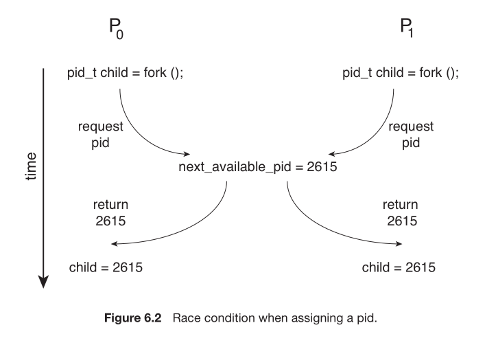

**Examples:**

1. **Open File List:** A kernel data structure that tracks all open files in the system. It must be updated every time a file is opened or closed. If two processes call `open()` simultaneously, their attempts to modify this shared list can interleave, corrupting it.
2. **Process ID Assignment (Go to Figure 6.2):** This figure illustrates a concrete race condition.
   - Two processes, `P0` and `P1`, concurrently call `fork()` to create child processes.
   - The kernel uses a shared global variable, `next_available_pid`, to assign the next unique Process Identifier (PID).
   - Without mutual exclusion, the following interleaving can occur:
     - Both `P0` and `P1` read the same value (e.g., 2615) from `next_available_pid`.
     - Both increment this value locally.
     - Both assign PID 2615 to their respective child processes.
     - The same PID is now assigned to two different processes, causing a serious error.

Other vulnerable kernel data structures include those for memory allocation, process lists, and interrupt handling. Eliminating such race conditions is a core responsibility of kernel developers.

#### **Naïve Approach: Disabling Interrupts**

In a **single-core (uniprocessor) system**, a crude solution exists:

- **Idea:** Prevent interrupts from occurring while a process is in its critical section.
- **Effect:** This guarantees the process will **not be preempted** (context-switched out) during its critical section. The sequence of instructions modifying the shared variable will run atomically from the scheduler's perspective.

**Why This Fails in Multiprocessors:**

1. **Performance Impact:** Disabling interrupts on **all** CPUs in a multiprocessor system requires time-consuming inter-processor communication, slowing down every entry into a critical section.
2. **System Function Impairment:** Many critical system functions (like the system clock) rely on timer interrupts. Disabling them would break these functions.
3. **Limited Scope:** It only prevents preemption from the scheduler. It does **nothing** to prevent a second process running **simultaneously on a different CPU core** from accessing the same shared data.

Therefore, disabling interrupts is generally **not a feasible general solution** for synchronization, especially in modern multiprocessor systems.

#### **Kernel Design Approaches: Preemptive vs. Nonpreemptive**

Operating system kernels adopt one of two general design philosophies regarding synchronization:

**1. Nonpreemptive Kernel:**

- **Definition:** A kernel where a process running in **kernel mode cannot be preempted**. It retains the CPU until it:
  - Exits kernel mode (returns to user mode),
  - Blocks (e.g., waits for I/O), or
  - Voluntarily yields the CPU.
- **Synchronization Implication:** Only **one process is active in the kernel at any time**. This inherently prevents race conditions on kernel data structures, as there is no concurrency *within the kernel itself*. Synchronization is simpler.

**2. Preemptive Kernel:**

- **Definition:** A kernel where a process running in **kernel mode can be preempted** (by a higher-priority process, often via a timer interrupt).
- **Synchronization Implication:** Multiple processes can be **concurrently active in the kernel**. This creates a risk of race conditions on shared kernel data. Designing such a kernel is **much more difficult**, especially for **Symmetric Multiprocessing (SMP)** systems where kernel code can literally run in parallel on multiple cores. It requires careful use of the synchronization tools discussed in this chapter.

**Why Choose a Preemptive Kernel?** Despite the complexity, preemptive kernels are favored because:

- **Responsiveness:** They prevent a poorly behaved kernel-mode process from monopolizing the CPU for arbitrarily long periods, leading to a **more responsive system** for interactive and real-time tasks.
- **Real-Time Suitability:** They allow a **real-time process** to immediately preempt a less critical process, even if it's in the kernel, which is essential for meeting strict timing deadlines.

## **6.3 Peterson's Solution**

#### **Introduction and Purpose**

Peterson's solution is a **classic, purely software-based algorithm** for solving the critical-section problem for two processes. It is an important intellectual exercise, but it comes with a critical caveat for modern systems:

**Important Disclaimer:** Due to the complexities of modern computer architecture (e.g., out-of-order execution, memory caching behavior), **Peterson's solution is not guaranteed to work correctly on real hardware** without special hardware support (like memory barriers, discussed later). We study it anyway because it:

1. Provides a clear **algorithmic description** of solving the critical-section problem.
2. Illustrates the **logical complexities** involved in satisfying all three requirements (mutual exclusion, progress, bounded waiting) in software.

#### **Problem Scope and Setup**

**Restrictions:**

- Designed for **exactly two processes**, labeled `P0` and `P1`.
- Uses the convention: For process `Pi`, the other process is `Pj`, where `j = 1 - i`.

**Shared Data Structures (Global variables both processes can access):**

1. **`int turn;`**
   - Indicates **whose turn it is** to enter the critical section.
   - If `turn == i`, process `Pi` is *allowed* to enter (but may still have to wait).
2. **`boolean flag[2];`**
   - An array of two boolean flags.
   - `flag[i] = true` signals that process `Pi` **is ready and wants** to enter its critical section.

#### **The Algorithm**

**Go to Figure 6.3** for the code structure. The algorithm for process `Pi` (where `j = 1 - i`) is:

```
while (true) {
    // ENTRY SECTION
    flag[i] = true;          // Step 1: I want to enter.
    turn = j;                // Step 2: Defer to the other process.

    // Busy-Wait Loop (part of entry section)
    while (flag[j] && turn == j)
        ; // Do nothing and wait.

    // CRITICAL SECTION
    /* Access and update shared data */

    // EXIT SECTION
    flag[i] = false;         // Step 3: I'm no longer interested.

    // REMAINDER SECTION
    /* Other code not using shared data */
}
```

#### **How It Works: A Walkthrough**

Let's break down the entry section logic:

1. **`flag[i] = true;`**
   - Process `Pi` **declares its interest** in entering the critical section. This is a public announcement.
2. **`turn = j;`**
   - Process `Pi` **politely gives the turn to the other process** (`Pj`). This act of "setting `turn` to the other process" is the key to ensuring bounded waiting and progress.
   - **The Race for `turn`:** If **both processes execute this line concurrently**, they will both try to write to the shared `turn` variable. Since writes are not atomic, one will overwrite the other. **The final saved value of `turn`** determines who "won" this polite race and gave away the turn last. The process that writes *second* essentially determines the final value.
3. **Busy-Wait Condition: `while (flag[j] && turn == j)`**
   - This is the **waiting loop**. Process `Pi` only proceeds into its critical section if this condition is **false**. Let's examine the two parts:
     - **`flag[j]` is true:** This means the other process (`Pj`) has expressed interest in entering (by executing its own `flag[j] = true`).
     - **`turn == j`:** This means it is currently the other process's (`Pj`'s) *turn* (according to the last value written to `turn`).
   - **Interpretation:** `Pi` will wait (spin) **only if** the other process is interested **AND** it is the other process's turn. If either condition is false, `Pi` proceeds.
     - If `flag[j]` is false, `Pj` isn't trying to enter, so `Pi` can go in.
     - If `turn == i`, then even if `Pj` is interested, it's `Pi`'s turn, so `Pi` proceeds.

**Key Insight:** The combination of `flag` and `turn` variables cleverly resolves contention:

- If only one process wants to enter (`flag` of the other is false), it proceeds immediately.
- If both want to enter, the **final value of `turn`** (determined by the last process to execute `turn = j`) breaks the tie. The process that *lost* the race to be polite (i.e., the one whose `turn = j` was overwritten) finds `turn == i` and enters. The other finds `turn == j` and waits.

**Exit Section:**

- `flag[i] = false;` signals that `Pi` is leaving and no longer needs the critical section, allowing the waiting process (if any) to proceed.

In the next part, we will analyze how this algorithm satisfies the three required properties.

### **Proof of Correctness**

We will now prove that Peterson's algorithm satisfies the three requirements for a correct solution to the critical-section problem.

#### **1. Proof of Mutual Exclusion**

We prove by **contradiction**. Assume the opposite: that **both** processes, `P0` and `P1`, are executing in their critical sections at the same time.

**What must be true if both are in their critical sections?** Each process `Pi` only enters its critical section when its **while loop condition is false**. Therefore, for both to be inside, the following must hold simultaneously:

- For `P0` to be in: `!(flag[1] && turn == 1)` must be true.
- For `P1` to be in: `!(flag[0] && turn == 0)` must be true.

Simplifying these, for both to be in their critical sections at once, **at least one** of the following compound conditions must be true:

- **Case A:** `flag[1] == false` (P1 isn't interested) **OR** `turn == 0` (it's P0's turn).
- **Case B:** `flag[0] == false` (P0 isn't interested) **OR** `turn == 1` (it's P1's turn).

However, if both processes are in their critical sections, they must have **first set their own flags to true** (`flag[0] = true` and `flag[1] = true`). So we know `flag[0] == true` and `flag[1] == true`. This eliminates the "flag false" parts of Cases A and B.

Therefore, for our initial assumption (both in CS) to hold with both flags true, we are left with:

- `turn == 0` must be true (from Case A, since `flag[1]==true`).
- `turn == 1` must also be true (from Case B, since `flag[0]==true`).

**This is impossible.** The shared variable `turn` cannot be both `0` and `1` at the same time. Our assumption leads to a contradiction.

**Conclusion:** It is **impossible** for both processes to be in their critical sections simultaneously. **Mutual exclusion is preserved.**

#### **2. Proof of Progress**

**Progress** requires that if no process is in its critical section and one or more want to enter, the selection of who enters next cannot be postponed indefinitely and must involve only those processes trying to enter.

**Informal Proof:** A process `Pi` can be stuck, prevented from entering its critical section, **only if** it is trapped in its `while` loop. The loop condition is `flag[j] && turn == j`. So, for `Pi` to be stuck, two things must be true forever:

1. `flag[j] == true` (the other process `Pj` is interested).
2. `turn == j` (it is persistently the other process's turn).

But `turn` is **only modified in the entry section** (by the statement `turn = j`). If `Pj` is stuck in the loop, it is not modifying `turn`. If `Pj` is in its remainder section, `flag[j]` is `false`. If `Pj` **enters its critical section**, it will **eventually exit** and set `flag[j] = false`, breaking condition (1) for `Pi`. The only way for `Pj` to keep `flag[j] == true` and `turn == j` forever is if `Pj` itself is stuck in *its* while loop—which requires `turn == i` and `flag[i] == true`. This creates a cyclical dependency that cannot hold because `turn` is a single, shared variable.

If both processes try to enter concurrently, the **race to set `turn`** decides who goes first. The process that *loses* this race (whose `turn = j` is overwritten) finds `turn == i` and proceeds. The process that *wins* the race (sets `turn` last) finds `turn == j` and waits, but only until the first process finishes and clears its flag.

Therefore, a process wishing to enter will **never be permanently blocked** by a process in its remainder section, and deadlock is impossible. **Progress is satisfied.**

#### **3. Proof of Bounded Waiting**

**Bounded Waiting** requires that once a process `Pi` has expressed a desire to enter (by setting `flag[i] = true`), there is a limit to how many times the other process `Pj` can enter its critical section before `Pi` gets its turn.

**Informal Proof:** Consider the point where `Pi` sets `flag[i] = true`. It then immediately sets `turn = j` (politely giving the turn away).

- **Scenario 1:** If `Pj` is not interested (`flag[j] == false`), `Pi` enters immediately. Waiting count = 0.
- **Scenario 2:** If `Pj` is also interested or becomes interested, we examine `turn`.
  - If `turn == i` at this point (meaning `Pj` set `turn = i` before `Pi` set `turn = j`), then `Pi` will enter immediately. Waiting count = 0.
  - If `turn == j` (meaning `Pi`'s write of `turn = j` occurred last), then `Pj` will proceed because it sees `turn == j` and `flag[i] == true`. **This is the only case where `Pi` must wait.**

**The Bound:** When `Pj` finishes its critical section, it sets `flag[j] = false` upon exiting. At this moment, the condition keeping `Pi` in its loop (`flag[j] && turn == j`) becomes **false** (because `flag[j]` is now false), and `Pi` can enter. Crucially, for `Pj` to **re-enter** its critical section *after* this, it must go through its entry section again, executing `turn = i`. This flips `turn` to `i`, guaranteeing that `Pi`'s waiting condition (`turn == j`) is now false, allowing `Pi` to proceed.

Thus, after `Pi` has set its flag to true, `Pj` can enter its critical section **at most once** before `Pi` is guaranteed entry. **The bound is 1. Bounded waiting is satisfied.**

**Summary:** Peterson's solution is a logically correct software algorithm that satisfies mutual exclusion, progress, and bounded waiting for two processes. Its primary educational value lies in demonstrating how to coordinate processes using shared variables, though it relies on assumptions about atomic memory operations that may not hold on real hardware.

### **Limitations on Modern Hardware**

#### **The Problem: Instruction Reordering**

As noted, Peterson's solution may **fail on modern computer architectures**. The primary reason is that to maximize performance, **processors** (via **out-of-order execution**) and **compilers** (via **code optimization**) may **reorder the sequence of read and write instructions**.

- **In Single-Threaded Programs:** This reordering is **safe and invisible**. The hardware/compiler guarantees the *final result* is as if the instructions executed in program order. It's like rearranging the order of adding deposits and subtracting checks in your checkbook—the final balance is correct.
- **In Multithreaded Programs with Shared Data:** This reordering can become **visible and disastrous**. Other threads may observe memory updates in an order different from the program's original sequence, leading to inconsistent or unexpected program states.

#### **Illustrative Example: A Broken Expectation**

Consider two threads sharing these variables:

```
boolean flag = false;
int x = 0;
```

- **Thread 1 executes:**

  ```
  while (!flag) ;  // Wait until flag becomes true
  print x;         // Then print x
  ```

- **Thread 2 executes:**

  ```
  x = 100;
  flag = true;
  ```

**Expected Behavior:** Thread 1 prints `100`. Thread 2 first sets `x` to 100, then signals Thread 1 by setting `flag` to true.

**How Reordering Breaks It:**

1. **Compiler/CPU Reorders Thread 2:** Since the two statements in Thread 2 are independent (neither depends on the other's result), the system might execute `flag = true` **before** `x = 100`. If this happens, Thread 1 could break out of its loop and print `x` **before** `x` is set to 100, resulting in output `0`.
2. **CPU Reorders Thread 1:** The processor could also reorder Thread 1's instructions, **loading the value of `x` into a register *before* it checks the value of `flag`**. Even if Thread 2 runs in perfect order, Thread 1 might have already cached the old value (`0`) of `x` before entering the loop, and then print that cached value.

#### **Impact on Peterson's Solution**

**Go to Figure 6.4**, which illustrates the failure.

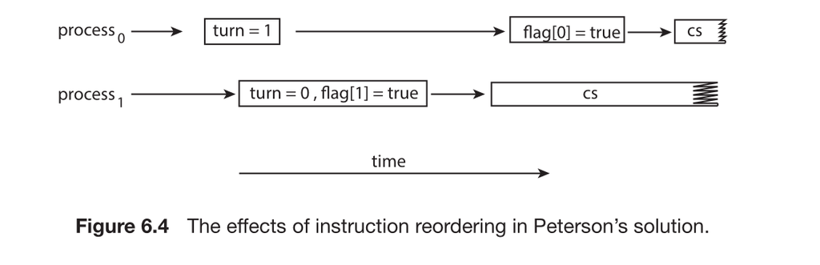

Recall Peterson's entry section for process `Pi`:

1. `flag[i] = true;`
2. `turn = j;`

**The Critical Assumption:** The algorithm assumes these two store instructions **execute and become visible to the other process in this exact order**. However, if the hardware or compiler reorders them so that `turn = j` becomes visible **before** `flag[i] = true`, mutual exclusion can be violated.

**Result:** **Both processes are now in their critical sections at the same time!** Mutual exclusion is broken.

#### **The Necessary Conclusion**

Peterson's solution demonstrates correct synchronization **logic**, but it relies on a **sequential consistency** memory model that modern systems do not provide for performance reasons. To implement correct synchronization on real hardware, we need:

1. **Hardware Support:** Mechanisms to **prevent problematic instruction reordering** and ensure certain memory updates become visible to other processors in a controlled manner.
2. **Proper Synchronization Tools:** APIs that leverage this hardware support to provide correct and reliable mutual exclusion.

The following sections will explore these solutions, starting with low-level hardware features and building up to high-level programming abstractions.

## **6.4 Hardware Support for Synchronization**

#### **Introduction: Moving Beyond Pure Software**

We've seen that pure software solutions like Peterson's algorithm are not reliable on modern hardware due to instruction reordering. To build **correct and efficient synchronization**, we need direct **hardware support**. This section covers three fundamental hardware instructions used to implement synchronization primitives. These low-level operations can be used directly by system programmers or as the building blocks for higher-level synchronization tools.

### **6.4.1 Memory Barriers (Memory Fences)**

#### **The Problem: Memory Models**

The issue of instruction reordering is governed by a processor's **memory model**, which defines the guarantees it provides about when a write by one processor becomes visible to others.

1. **Strongly Ordered Memory Model:**
   - Any modification to memory by one processor is **immediately visible to all other processors**.
   - This simplifies reasoning but limits performance optimizations.
2. **Weakly Ordered Memory Model (Common in Modern Architectures):**
   - Modifications to memory by one processor **may not be immediately visible** to others.
   - Processors and compilers can aggressively reorder reads and writes for speed, as long as the *single-threaded* result is preserved.

Since memory models vary, programmers cannot make assumptions. To write correct concurrent code, we need a way to explicitly enforce ordering.

#### **The Solution: Memory Barrier Instruction**

A **memory barrier** (or **memory fence**) is a special hardware instruction that enforces ordering constraints on memory operations.

- **What it does:** When a memory barrier is executed, it guarantees that **all load and store operations issued *before* the barrier are completed** (i.e., their results are visible in main memory and to other processors) **before *any* load or store operation issued *after* the barrier can begin**.
- **Effect:** It prevents the hardware or compiler from reordering memory accesses across the barrier. It also ensures that writes performed on the current CPU are flushed to memory, making them visible to other CPUs.

#### **Fixing the Earlier Example with Memory Barriers**

Recall the example where Thread 2 sets `x = 100;` then `flag = true;`.

**Without a barrier:** The two stores could be reordered, causing Thread 1 to see `flag = true` while `x` is still `0`.

**Adding a memory barrier in Thread 2:**

```
x = 100;
memory_barrier(); // Ensures x=100 is globally visible BEFORE flag=true
flag = true;
```

Now, the assignment to `x` is guaranteed to complete and be visible **before** the assignment to `flag` begins. This restores the logical order.

**Adding a memory barrier in Thread 1:** Thread 1 waits for the flag: `while (!flag) ;` Even after the loop ends, the CPU might have **pre-fetched** the old value of `x` into a register.

```
while (!flag)
    ;
memory_barrier(); // Ensures flag is truly loaded and checked before loading x
print x;
```

This barrier ensures the load of `flag` and the exit from the loop are fully completed **before** the load of `x` is performed, guaranteeing it sees the updated value.

#### **Applying a Memory Barrier to Peterson's Solution**

Referring back to **Figure 6.4**, the problem occurred because `turn = j` could become visible before `flag[i] = true`. To fix this, we insert a memory barrier **between** the two assignment statements in the entry section:

```
flag[i] = true;
memory_barrier(); // CRITICAL: Ensure flag[i]=true is visible before turn=j
turn = j;
while (flag[j] && turn == j)
    ;
// ... critical section ...
```

This barrier prevents the reordering that broke mutual exclusion, making Peterson's algorithm safe on architectures that provide this instruction.

**Important Note:** Memory barriers are **very low-level, hardware-specific instructions**. They are primarily used by **kernel and system-level developers** when implementing the core synchronization primitives (like locks) that higher-level applications will use. Application programmers typically use those higher-level primitives (e.g., mutexes) rather than memory barriers directly.

### **6.4.2 Hardware Instructions**

#### **Introduction: Atomic Hardware Primitives**

To build efficient synchronization, we need hardware instructions that can perform a **read, a test, and a write** to memory as a single, **indivisible (atomic)** operation. These special instructions form the foundation upon which all higher-level synchronization tools (like mutexes and semaphores) are built.

Two classic abstract models for such instructions are `test_and_set()` and `compare_and_swap()`. They are implemented as single, uninterruptible machine instructions on modern CPUs (e.g., `xchg` on x86, `ldrex`/`strex` on ARM).

#### **The `test_and_set()` Instruction**

**Go to Figure 6.5** for its definition. The `test_and_set()` instruction operates on a boolean value in memory.

**Definition:**

```
boolean test_and_set(boolean *target) {
    boolean rv = *target; // Step 1: Read the old value
    *target = true;       // Step 2: Always set it to true (atomically with the read)
    return rv;            // Step 3: Return the OLD value
}
```

**Key Property: Atomicity** The entire sequence—reading the old value and writing `true`—is executed **atomically**. If two CPUs execute `test_and_set()` on the same memory location simultaneously, the hardware guarantees they will be serialized (executed one after another in some order), and the combined read-write operations will not be interleaved.

#### **Implementing Mutual Exclusion with `test_and_set()`**

**Concept:** We use a shared **boolean lock variable**, initialized to `false`.

- `lock == false` means the critical section is **available**.
- `lock == true` means the critical section is **occupied**.

**The Algorithm (Go to Figure 6.6):**

```
// Shared variable
boolean lock = false;

// Process Pi
do {
    // ENTRY SECTION: Acquire the lock
    while (test_and_set(&lock))
        ; // Busy-wait (spin) if lock was already true

    // CRITICAL SECTION
    // ... access shared data ...

    // EXIT SECTION: Release the lock
    lock = false;

    // REMAINDER SECTION
} while (true);
```

#### **How It Works Step-by-Step:**

1. **Entry (Acquiring the lock):**
   - A process calls `test_and_set(&lock)`.
   - **Atomically**, the instruction: a. Reads the **current** value of `lock`. b. Sets `lock` to `true`. c. Returns the **old** value it just read.
   - **Case 1: Lock was `false` (available).** The instruction returns `false` and simultaneously sets `lock` to `true`. Since the `while` condition is `false`, the process **exits the loop and enters its critical section**. It has successfully acquired the lock.
   - **Case 2: Lock was `true` (busy).** The instruction returns `true` (and also sets `lock` to `true` again, which is redundant). The `while` condition is `true`, so the process **continues to spin (busy-wait)** until the lock becomes free.
2. **Critical Section:**
   - The process executes its critical section code. Because `lock` is `true`, any other process trying to enter will get `test_and_set()` returning `true` and will spin.
3. **Exit (Releasing the lock):**
   - The process simply sets `lock = false`. This makes the lock available again.
   - One of the waiting processes (spinning in its `while` loop) will now, on its next `test_and_set()` call, read this `false`, set `lock` to `true`, and enter.

#### **Analysis Against the Three Requirements:**

- **Mutual Exclusion:** **YES.** The atomicity of `test_and_set()` is crucial. It guarantees that exactly one process will see `lock == false` and enter. The first process to atomically set `lock` to `true` wins; all others find it already `true` and wait.
- **Progress:** **YES.** When a process leaves its critical section (sets `lock = false`), any process waiting in the entry section will immediately call `test_and_set()`. The one that executes it next will atomically capture the lock and enter. The decision is made by the hardware arbitration of who executes the atomic instruction next—processes in the remainder section do not participate.
- **Bounded Waiting:** **NO.** This simple implementation **does not guarantee bounded waiting**. It's possible that a process could be starved indefinitely if other processes repeatedly acquire the lock just before it gets a chance to execute its `test_and_set()` instruction. The waiting process has no priority; it's just one of many spinning contenders.

**Summary:** The `test_and_set()` instruction provides a simple, hardware-based way to enforce mutual exclusion with progress. However, the resulting **spinlock** causes busy-waiting and, in its basic form, does not prevent starvation. It's most useful in multiprocessor systems when the expected wait time for a lock is very short.

#### **The `compare_and_swap()` (CAS) Instruction**

The **`compare_and_swap()` (CAS)** instruction is a more general and powerful atomic primitive than `test_and_set()`. It operates on three operands.

**Definition (Go to Figure 6.7):**

```
int compare_and_swap(int *value, int expected, int new_value) {
    int temp = *value;                  // Step 1: Atomically read current value
    if (*value == expected)             // Step 2: Compare (still part of atomic op)
        *value = new_value;             // Step 3: Conditionally update
    return temp;                        // Return the ORIGINAL value read in Step 1
}
```

**How it works atomically:**

1. It reads the current contents of memory location `*value`.
2. It compares this read value to the `expected` argument.
3. **If and only if they match**, it writes `new_value` into the location.
4. **It always returns the original value** it read in step 1, regardless of whether the swap occurred.

The entire sequence is executed as a single, uninterruptible hardware instruction.

#### **Basic Mutual Exclusion Using CAS**

**Concept:** Use a shared integer `lock`, initialized to `0`.

- `lock == 0` means the critical section is **available**.
- `lock == 1` means the critical section is **occupied**.

**The Algorithm (Go to Figure 6.8):**

```
// Shared variable
int lock = 0;

// Process Pi
while (true) {
    // ENTRY SECTION
    while (compare_and_swap(&lock, 0, 1) != 0)
        ; // Spin while the returned original value is NOT 0

    // CRITICAL SECTION
    // ... access shared data ...

    // EXIT SECTION
    lock = 0;

    // REMAINDER SECTION
}
```

**Walkthrough:**

- A process tries to enter by calling `compare_and_swap(&lock, 0, 1)`.
  - If `lock` is currently `0` (expected), the CAS **atomically** swaps it to `1` and returns the original value `0`. The process exits the spin loop and enters its critical section.
  - If `lock` is currently `1`, the CAS finds `lock (1) != expected (0)`, so it does **not** change `lock` (it stays `1`), but returns the original value `1`. Since the return value is `!= 0`, the process continues to spin.
- Upon exit, the process simply resets `lock = 0`.

**Analysis:** This simple CAS lock has the **same properties** as the simple `test_and_set()` lock: it ensures **Mutual Exclusion** and **Progress**, but **does NOT satisfy Bounded Waiting** (starvation is possible).

#### **Achieving Bounded Waiting with CAS**

**Go to Figure 6.9** for a more sophisticated algorithm that uses CAS to satisfy **all three requirements**, including bounded waiting, for `n` processes.

**Shared Data Structures:**

```
boolean waiting[n]; // Each process has its own flag, initialized to false
int lock = 0;       // Global lock, initialized to 0
```

**Algorithm for Process Pi:**

```
while (true) {
    // ENTRY SECTION
    waiting[i] = true;                     // I'm waiting to enter
    int key = 1;
    // Spin until: I'm not waiting OR I successfully acquire the lock
    while (waiting[i] && key == 1)
        key = compare_and_swap(&lock, 0, 1); // Try to atomically grab the lock
    waiting[i] = false;                    // I'm no longer waiting (I'm entering)

    // CRITICAL SECTION
    // ... access shared data ...

    // EXIT SECTION (Finds next waiter in round-robin order)
    int j = (i + 1) % n;                   // Start scanning after me
    while (j != i && !waiting[j])          // Find the next waiting process
        j = (j + 1) % n;

    if (j == i)                            // Case 1: No one is waiting
        lock = 0;                          // Just release the global lock
    else                                   // Case 2: Process j is waiting
        waiting[j] = false;                // Directly pass the lock to j

    // REMAINDER SECTION
}
```

**How It Satisfies the Requirements:**

- **Mutual Exclusion:** The `lock` variable ensures it. Only the first process to succeed in the CAS sets `lock=1`. That process proceeds only when `waiting[i]` becomes false (which happens after it acquires the lock). Others spin because their `key` remains `1` (CAS fails while `lock==1`).
- **Progress:** When a process exits:
  - If no one is waiting, it sets `lock=0`, allowing the next process that arrives to acquire it via CAS.
  - If someone is waiting, it **directly sets that waiter's flag to `false`**. This immediately allows that specific waiting process to exit its spin loop (`waiting[j]` is now false) and enter the critical section. The lock transfer is explicit and immediate.
- **Bounded Waiting (The Key Innovation):** The exit section implements a **round-robin scan**. A departing process searches the `waiting` array in a cyclic order starting from the next process. It **grants the lock to the first waiting process it finds**. Therefore, any waiting process will be granted the lock **no later than** after every other process has entered at most once. The bound is `n-1` turns.

**Summary:** The `compare_and_swap()` instruction is a versatile building block. It can be used to implement simple spinlocks or, with additional data structures like a waiting array, to build sophisticated, fair locks that prevent starvation. This demonstrates how hardware atomic instructions serve as the foundation for all higher-level synchronization constructs.

#### **Making CAS Atomic in Hardware**

**Implementation on Intel x86:** The CAS functionality is provided by the `cmpxchg` (compare and exchange) assembly instruction. To ensure it is atomic across multiple CPUs, it is prefixed with the **`lock`** instruction.

**Format:**

```
assembly
lock cmpxchg <destination operand>, <source operand>
```

The `lock` prefix locks the system bus (or uses a cache-coherence protocol) for the duration of the operation, preventing any other CPU from accessing the destination memory location. This guarantees the entire read-modify-write cycle is seen by all processors as atomic.

**Summary:** CAS is a versatile atomic primitive. Its basic use creates a simple spinlock. With additional logic (like a waiting array and round-robin scanning), it can be used to build sophisticated, fair synchronization mechanisms that satisfy all critical-section requirements.

### **6.4.3 Atomic Variables**

#### **Introduction: A Higher-Level Abstraction**

The `compare_and_swap()` (CAS) instruction is powerful but low-level. Programmers rarely use it directly. Instead, it serves as the fundamental building block for more convenient synchronization tools. The first such tool we examine is the **atomic variable**.

**Purpose:** An atomic variable provides a set of **atomic (indivisible) operations** on basic data types (integers, booleans). Its primary use is to prevent **race conditions that involve updates to a single shared variable**, like incrementing a counter (`count++`).

**Recall from Section 6.1:** Our producer-consumer example failed because `count++` was not atomic—it involved separate read, modify, and write steps. An atomic integer would solve that specific race condition on the `count` variable itself.

#### **How Atomic Variables Work**

Systems that support atomic variables provide:

1. **Special Atomic Data Types** (e.g., `atomic_int`, `atomic_bool`).
2. **Associated Functions** to operate on them (e.g., `increment()`, `load()`, `store()`, `compare_exchange_strong()`).

**Under the Hood:** These functions are implemented using hardware atomic instructions like **`compare_and_swap()` (CAS)**.

**Example: Implementing `increment()` with CAS** The text shows how to build an atomic increment operation from CAS. The logic is a common pattern known as a **CAS loop** or **optimistic concurrency control**.

```
void increment(atomic_int *v) {
    int temp;
    do {
        temp = *v; // Read the current value of the atomic variable
        // Try to swap. If *v hasn't changed since we read it (== temp),
        // set it to temp+1. If it has changed, the swap fails, and we retry.
    } while (temp != compare_and_swap(v, temp, temp + 1));
}
```

**How the CAS Loop Works:**

1. Read the current value of the shared atomic variable into a local `temp`.
2. Use **CAS** to attempt an update: "If `*v` still equals my `temp`, set it to `temp+1`."
3. CAS **atomically** checks and updates. If it succeeds (returns the original value which equals `temp`), the loop ends—the increment is done.
4. If CAS fails (returns a different value because another thread changed `*v` in the meantime), the loop **retries** from step 1 with the new value.

This ensures the increment happens atomically, without a separate lock. The process is "optimistic": it proceeds assuming no conflict, and only retries if a conflict is detected by the CAS.

#### **Important Limitations of Atomic Variables**

**Critical Caveat:** Atomic variables **do NOT solve all synchronization problems**. They only guarantee atomicity for operations **on that single variable**. They do not provide mutual exclusion for **compound operations** or **coordination between multiple variables**.

**Illustration with the Bounded-Buffer Problem:** Suppose we correctly make `count` an atomic integer. This ensures that `count++` and `count--` are atomic. However, the **race condition is not fully solved**.

**Problem Scenario:**

- Buffer is empty. `count == 0`.
- Two consumers, `C1` and `C2`, both execute their `while (count == 0)` loop.
- A producer adds one item and performs `increment(&count)`. `count` is now atomically set to `1`.
- **Both `C1` and `C2` can now see `count == 1` and exit their `while` loops simultaneously.**
- Both proceed to consume the same single item, leading to data corruption or an attempt to consume from an empty buffer.

**The Root Cause:** The atomic variable protects the **update** of `count`, but the **check-then-act** sequence (`while (count == 0)` followed by `count--` and buffer access) is **not atomic as a whole**. The consumers make a decision based on `count` and then act on it, but another thread can intervene between the check and the act.

#### **When to Use Atomic Variables**

Atomic variables are ideal for specific, simple scenarios:

- **Shared counters** (e.g., statistics, sequence number generators).
- **Status flags** (e.g., a boolean `shutdown_requested` flag).
- **Simple bitmasks.**

They are **not sufficient** for coordinating access to complex data structures (like a bounded buffer queue) or for enforcing invariants that depend on multiple shared variables. For those, you need the more robust synchronization tools discussed next: **mutex locks, semaphores, and monitors**, which can guard entire sections of code and coordinate actions between multiple threads. Atomic variables are a valuable tool in the concurrency toolkit, but they are just one part of the solution.

## **6.5 Mutex Locks**

#### **Introduction: Higher-Level Synchronization Tools**

The hardware instructions (`test_and_set()`, `compare_and_swap()`) are powerful but low-level and complex to use directly. To make synchronization accessible to application programmers, operating systems provide **higher-level software abstractions**. The simplest and most fundamental of these is the **mutex lock** (short for "mutual exclusion lock").

**Purpose:** A mutex lock is used to **protect critical sections** and thereby prevent race conditions. The rule is simple:

1. A process must **acquire** the lock **before** entering its critical section.
2. It **releases** the lock **after** exiting its critical section.

**General Structure (Go to Figure 6.10):**

```
while (true) {
    acquire_lock();   // ENTRY SECTION: Get the lock
    // CRITICAL SECTION
    release_lock();   // EXIT SECTION: Release the lock
    // REMAINDER SECTION
}
```

#### **Basic Mutex Lock Implementation**

A mutex lock is represented internally by a **boolean variable**, typically named `available` (or `locked`).

- `available == true`: The lock is **free**, no one holds it.
- `available == false`: The lock is **busy**, held by some process.

**The `acquire()` function:**

```
acquire() {
    while (!available)
        ; /* BUSY WAIT - spin until lock becomes true */
    available = false; // Atomically take the lock
}
```

**The `release()` function:**

```
release() {
    available = true; // Atomically release the lock
}
```

**Critical Requirement:** The **entire** `acquire()` function (the check of `available` and the subsequent setting to `false`) must be executed **atomically**. If not, two processes could both see `available == true` simultaneously and both believe they acquired the lock. This atomicity is achieved by implementing these functions using the **hardware atomic instructions** (like `compare_and_swap()`) discussed in Section 6.4.

#### **The Busy-Waiting Problem and Spinlocks**

The simple mutex implementation shown above has a major drawback: **busy waiting**.

- **What is Busy Waiting?** If a process finds the lock unavailable (`available == false`), it enters a tight loop (`while (!available) ;`), continuously checking the lock's status. This is called **spinning**.
- **Why it's Bad (especially on single-core systems):** Busy waiting **wastes CPU cycles**. While one process holds the lock in its critical section, another process (or other ready processes) could be using the CPU productively. On a single CPU, the spinning process prevents the lock-holder from being scheduled to finish and release the lock, potentially leading to a deadlock scenario.

Because of this spinning behavior, a mutex lock implemented this way is specifically called a **spinlock**.

#### **When Are Spinlocks Actually Useful?**

Despite the waste, spinlocks have a crucial advantage: **They avoid a context switch.**

- **Context Switch Cost:** Switching a process off the CPU (saving its state, loading another's) is a relatively expensive operation.
- **The Trade-off:** If the **expected wait time for a lock is very short** (shorter than the time it would take to do a context switch), then it is **more efficient** to have the waiting process spin briefly than to incur the overhead of putting it to sleep and later waking it up.
- **Ideal Use Case:** **Multicore systems**, where one thread can spin on Core A while the lock holder executes its short critical section on Core B. The spinning thread will see the lock released almost immediately without any expensive OS intervention.

**Conclusion:** Spinlocks are **widely used in operating system kernels** for protecting short-duration critical sections, especially on multiprocessor systems. For user-level applications where hold times may be longer, alternative mechanisms that avoid busy waiting (like those putting the process to sleep) are preferred.

#### **Looking Ahead**

- The next section (6.6) introduces synchronization tools (like **semaphores**) that avoid busy waiting by putting waiting processes into a **sleep state**.
- Chapter 7 will show practical applications of mutex locks to solve classical synchronization problems.
- Mutex locks and spinlocks are foundational constructs used in real systems like Linux, Windows, and the Pthreads (POSIX threads) library.

**In summary:** A mutex lock is a software abstraction that provides mutual exclusion. Its simplest implementation is a spinlock, which is efficient for short waits on multiprocessors but wasteful for long waits. The atomicity of the lock operations is guaranteed by underlying hardware instructions.

#### **Lock Contention**

**Contention** refers to competition for a lock.

- **Uncontended Lock:** A lock is **uncontended** when a thread tries to `acquire()` it and it is **immediately available**. This is the ideal, low-overhead case.
- **Contended Lock:** A lock is **contended** when a thread tries to `acquire()` it and finds it **already held**, forcing the thread to wait (either by spinning or blocking).
  - **Low Contention:** Few threads compete for the lock.
  - **High Contention:** Many threads frequently compete for the lock. High contention is a major source of performance degradation in concurrent programs, as threads spend most of their time waiting.

#### **Defining "Short Duration" for Spinlocks**

The guideline for using a spinlock is that the lock should be held for a **"short duration."** Quantitatively, this means: **The expected time the lock will be held should be LESS than the time it would take to perform two context switches.** If the hold time is longer, the wasted CPU cycles from spinning outweigh the context-switch overhead, and a **blocking lock** (which puts waiting threads to sleep) is a better choice. The next section (6.6) explores locks that avoid busy-waiting.

## **6.6 Semaphores**

#### **Introduction: A More Robust Synchronization Tool**

Mutex locks enforce simple mutual exclusion. **Semaphores** are a more general and powerful synchronization primitive introduced by Edsger Dijkstra. A semaphore is a **shared integer variable** that can only be manipulated via two atomic operations.

**Definitions (using Dijkstra's original terminology):**

- **`wait(S)`** (also called **`P(S)`** from Dutch *proberen*, "to test"): Decrements the semaphore value. If the value becomes negative, the process executing `wait()` must wait.
- **`signal(S)`** (also called **`V(S)`** from Dutch *verhogen*, "to increment"): Increments the semaphore value. If any processes are waiting, one may be resumed.

**Crucial Requirement:** The operations on the integer `S`—especially the **test and decrement in `wait()`**—must be **executed atomically**. No two processes can execute `wait()` or `signal()` on the same semaphore simultaneously. Their implementation relies on lower-level hardware atomic instructions (see Section 6.6.2).

#### **6.6.1 Semaphore Usage**

##### **Types of Semaphores**

1. **Binary Semaphore:**
   - Integer value range: **0 or 1**.
   - Functionally equivalent to a **mutex lock**.
   - `wait()` acquires the lock; `signal()` releases it.
2. **Counting Semaphore:**
   - Integer value can range over any **non-negative integer**.
   - Used to manage access to a **pool of identical resources** with a finite number of instances.

##### **Using Counting Semaphores for Resource Management**

**Scenario:** A system has `N` identical instances of a resource (e.g., 5 tape drives, 3 printer ports).

**Implementation:**

- Initialize the semaphore `S` to `N` (the total number of available resources).
- **Each process must:**
  1. **`wait(S)` before using a resource.** This atomically decrements `S`. If `S > 0`, a resource is available and the process proceeds. If `S == 0`, all resources are in use, and the process must **block** (or busy-wait in the simple definition) until one becomes free.
  2. **Use the resource** (its critical section).
  3. **`signal(S)` after finishing with the resource.** This atomically increments `S`, signaling that a resource has been returned to the pool.

**Example:** With `N=3`, `S` starts at 3. The first three processes calling `wait(S)` will get `S=2,1,0` and proceed. A fourth process calling `wait(S)` will find `S <= 0` and must wait. When a process calls `signal(S)`, `S` becomes 1, and a waiting process can be awakened.

##### **Using Semaphores for Process Synchronization (Ordering)**

Semaphores can enforce **execution order** between processes, not just mutual exclusion.

**Problem:** Ensure statement `S2` in process `P2` executes **only after** statement `S1` in process `P1` has completed.

**Solution:**

1. Create a semaphore `synch` and initialize it to **0**.
2. **Process P1:**

   ```
   S1;              // Execute the first statement
   signal(synch);   // Signal that S1 is done (increments synch to 1)
   ```

3. **Process P2:**

   ```
   wait(synch);     // Wait for the signal from P1. If synch=0, block.
   S2;              // Execute only after P1's signal
   ```

**How it works:**

- If `P2` reaches `wait(synch)` **before** `P1` executes `signal(synch)`, the semaphore value is 0. `P2` will block (wait).
- When `P1` later executes `S1` followed by `signal(synch)`, it increments `synch` to 1. This unblocks `P2`, allowing `S2` to run.
- If `P1` signals first, `synch` becomes 1. When `P2` later calls `wait(synch)`, it finds `synch > 0`, decrements it to 0, and proceeds immediately without blocking.

This pattern is fundamental for coordinating tasks (e.g., producer-consumer, where the consumer must wait for the producer to create data).

### **6.6.2 Semaphore Implementation**

#### **Eliminating Busy-Waiting: The Blocking Semaphore**

The simple definitions of `wait()` and `signal()` presented earlier suffered from **busy-waiting**, just like the basic spinlock. To solve this, we modify the implementation so that a process **blocks** (suspends itself) when it must wait, allowing the CPU to be used by other processes.

#### **The Semaphore Data Structure**

A semaphore is now defined as a record (struct) containing:

1. **`value`:** An integer (which can now be negative).
2. **`list`:** A queue (linked list) of processes (or threads) blocked and waiting on this semaphore.

```
typedef struct {
    int value;
    struct process *list; // Pointer to the head of a waiting queue
} semaphore;
```

**Important Interpretation of `value`:**

- **`value >= 0`:** The number of **available resource instances** (for counting semaphores) or indicates the lock is free (for binary semaphores).
- **`value < 0`:** The **magnitude (absolute value)** of `value` indicates the **number of processes currently blocked** in the semaphore's waiting queue. (e.g., `value = -3` means 3 processes are waiting.)

#### **Blocking Implementation of `wait()`**

```
wait(semaphore *S) {
    S->value--;               // 1. Decrement the value first.
    if (S->value < 0) {       // 2. Check if we need to block.
        // No resources available or lock is busy.
        add this process to S->list; // 3. Enqueue itself on the wait list.
        sleep();                     // 4. Block: Process state -> WAITING.
                                     //    CPU scheduler picks a new process.
    }
}
```

**Step-by-Step Logic:**

1. **Atomically decrement `value`.** This "takes a ticket" or "attempts to acquire."
2. **Check the result.**
   - If `value >= 0` after decrement, the process successfully acquired a resource/the lock and proceeds to its critical section **immediately**.
   - If `value < 0` after decrement, it means no resource was available **or** the decrement made the count negative. The process must **block**.
3. **Blocking:** The process adds its own Process Control Block (PCB) to the semaphore's waiting queue and calls `sleep()`. This is a system call that changes the process state from RUNNING to WAITING (or BLOCKED) and invokes the scheduler to run a different process.

#### **Blocking Implementation of `signal()`**

```
signal(semaphore *S) {
    S->value++;               // 1. Increment the value.
    if (S->value <= 0) {      // 2. Check if processes are waiting.
        // There are blocked processes (value was -1 or less before increment).
        remove a process P from S->list; // 3. Dequeue a waiting process.
        wakeup(P);                       // 4. Wake it: Process state -> READY.
    }
}
```

**Step-by-Step Logic:**

1. **Atomically increment `value`.** This "returns a resource" or "releases the lock."
2. **Check if processes are waiting.**
   - If `value <= 0`, it means **before** the increment, `value` was `<= -1`. This indicates there is at least one process waiting. The increment only raised the count (e.g., from -2 to -1), but it's still negative, so waiters remain.
   - If `value > 0` after the increment, it means no processes were waiting (the queue was empty).
3. **Wake-up:** If processes are waiting, remove **one** process from the waiting queue (the choice depends on queue policy, e.g., FIFO for fairness). Call `wakeup(P)`, a system call that moves that process from the WAITING state to the READY state, placing it in the ready queue for the scheduler.

#### **Key Implementation Details**

1. **Atomicity of Operations:** The **entire `wait()` and `signal()`** functions (the decrement/increment plus the check) **must be atomic**. This is itself a **critical-section problem**.
   - **On a uniprocessor:** Can be implemented by **disabling interrupts** during the operation to prevent context switches.
   - **On a multiprocessor (SMP):** Disabling interrupts on all cores is impractical. The atomicity must be ensured using **lower-level spinlocks or atomic hardware instructions** (like `compare_and_swap()`) **within** the `wait()`/`signal()` implementation itself. This means short **busy-waiting occurs inside the semaphore implementation**, but it's confined to a few instructions.
2. **Waiting Queue Management:** The waiting list is typically a FIFO queue (to ensure **bounded waiting** and prevent starvation), but other policies are possible. The queue is managed via pointers in the Process Control Block (PCB).

#### **Why This is Efficient: Minimizing Busy-Waiting**

We have **not eliminated busy-waiting entirely**, but we have **contained and minimized it**.

- **Busy-waiting is now confined** to the **very short critical sections inside `wait()` and `signal()`** themselves, which are protected by a low-level spinlock or interrupt disabling. These sections are only a few instructions long.
- **Application processes no longer busy-wait.** They **block** and free the CPU if the semaphore is unavailable. This is crucial when the wait time is long (minutes/hours) or critical sections are large.

**Contrast with Spinlocks:** A spinlock forces **every waiting process** to busy-wait for the **entire duration** of the holder's critical section. With blocking semaphores, only the **internal implementation lock** might involve a brief spin, while **user processes sleep peacefully**.

This efficient, blocking implementation is the standard semaphore used in practice.

## **6.7 Monitors**

#### **The Problem: Correct but Error-Prone Synchronization**

While semaphores and mutex locks are powerful tools, they are **low-level** and **error-prone**. Their correct use relies entirely on the programmer's discipline to:

1. Call `wait()` (or `acquire()`) **before** entering a critical section.
2. Call `signal()` (or `release()`) **after** exiting the critical section.
3. Never make a mistake in the order or number of these calls.

Because these operations are called **explicitly** from the general code, it's easy to make subtle, hard-to-detect bugs.

#### **Illustration of Common Semaphore/Mutex Errors**

Consider the standard pattern for mutual exclusion using a binary semaphore `mutex` initialized to 1:

**Correct Pattern:**

```
wait(mutex);   // ENTRY
// CRITICAL SECTION
signal(mutex); // EXIT
```

**Potential Catastrophic Errors:**

1. **Reversed Order:**

   ```
   signal(mutex);  // WRONG: Signals without holding!
   // CRITICAL SECTION
   wait(mutex);    // WRONG: Tries to acquire after!
   ```

   **Result:** **Mutual exclusion is completely violated.** Multiple processes can enter the critical section concurrently. This bug may only surface rarely under specific interleavings, making it a **heisenbug**—hard to reproduce and detect.
2. **Double `wait()` (Deadlock):**

   ```
   wait(mutex);
   // CRITICAL SECTION
   wait(mutex); // WRONG: Waits again on the same lock!
   ```

   **Result:** The process **deadlocks itself permanently** on the second `wait()`, because it is waiting for a lock it already holds and will never release.
3. **Omitted Operations:**
   - **Omit `wait(mutex)`:** ➜ Mutual exclusion is violated.
   - **Omit `signal(mutex)`:** ➜ The lock is never released, causing **all other processes to permanently block** (deadlock) when they try to acquire it.
   - **Omit both:** ➜ Chaos (no synchronization at all).

These errors can arise from simple typos, copy-paste mistakes, complex control flow (like early returns in the critical section), or exception handling.

#### **The Solution Idea: High-Level Language Constructs**

The fundamental issue is that synchronization is **separate from** the resource it protects. The compiler and runtime system have no way of knowing *which* shared data a particular mutex is supposed to guard.

**The Strategy:** To prevent these errors, we can **embed synchronization directly into the programming language**. The language construct should:

1. **Encapsulate** the shared data and the synchronization that protects it into a single, indivisible unit.
2. **Automatically** enforce the correct acquisition and release of locks, making it **impossible** for a programmer to forget or misorder the calls.

#### **Introducing the Monitor**

The **monitor** is a **high-level synchronization abstraction** provided by certain programming languages (like Java `synchronized` methods, or Mesa/Cedar). It directly addresses the problems above.

**A monitor is a collection of:**

1. **Shared Data Variables:** The resources or state that need to be protected.
2. **Procedures (or Methods)** that operate on that shared data.
3. **An Implicit Lock (Mutex):** Every monitor has an associated lock, but it's managed automatically.
4. **Initialization Code:** To set up the shared data.

**Key Enforcement Rule (The Big Idea):**

- **Only one process/thread can be *active* (executing any procedure) inside the monitor at any given time.** The language runtime **automatically acquires the monitor's lock when a thread enters any of its procedures and releases it when the thread leaves.**
- This makes the entire set of procedures **implicitly mutually exclusive**. The programmer **cannot** forget to acquire or release the lock—it's handled by the language.

**Result:** The simple, error-prone pattern:

```
acquire(lock);
modify_shared_data();
release(lock);
```

is replaced by a structured, safer pattern:

```
monitor Resource {
    private shared_data;

    public procedure modify() {
        // Compiler/runtime automatically acquires lock here.
        // ... safely modify shared_data ...
        // Lock is automatically released upon return.
    }
}
```

By bundling the data and the operations together and letting the language manage the lock, monitors eliminate entire classes of synchronization bugs. However, monitors introduce a new need: a way for threads to wait for specific **conditions** (e.g., a consumer waiting for a buffer to be non-empty). This leads to the companion concept of **condition variables**, which we will explore next.

### **6.7.1 Monitor Usage**

#### **Monitors as an Abstract Data Type (ADT)**

A monitor is essentially a **specialized Abstract Data Type (ADT)**.

- A regular ADT encapsulates data and the operations (functions) on that data, hiding the implementation details.
- A **monitor type** does this **and additionally guarantees mutual exclusion** for all its operations. It's an ADT with built-in synchronization.

**Syntax (Go to Figure 6.11):**

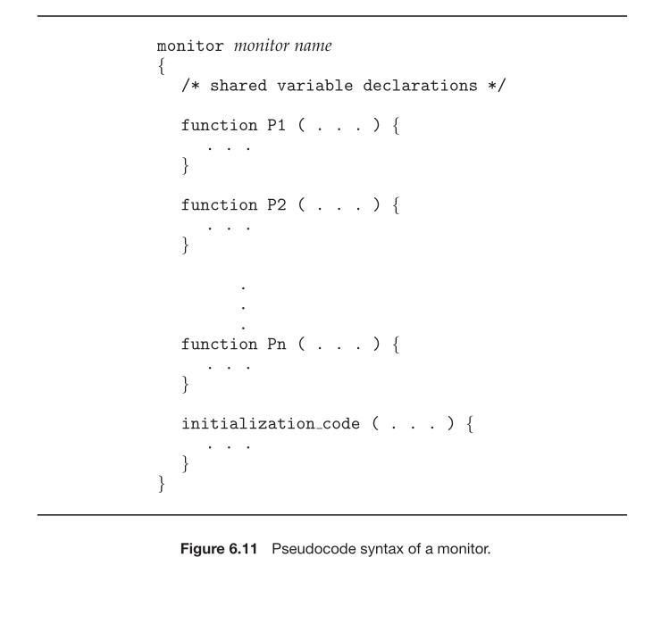

The monitor defines:

1. **Private/Shared Variables:** The internal state that needs protection.
2. **Public Procedures/Functions (`P1`, `P2`, ... `Pn`):** The **only** way to access or modify the shared variables. These are the monitor's interface.
3. **Initialization Code:** Runs once to set up the initial state.

**Crucial Access Rule:**

- The shared variables are **only accessible from within the monitor's procedures**. External processes cannot touch them directly.
- The monitor's procedures can only access their own local variables and parameters.

#### **Automatic Mutual Exclusion: The Core Benefit**

**Go to Figure 6.12** for a schematic view. The monitor runtime enforces a fundamental rule: **Only one process/thread can be *actively executing* inside any of the monitor's procedures at any time.**

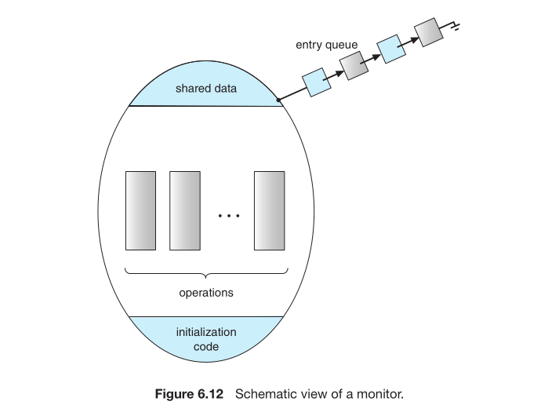

**How it works:**

- When a process calls a monitor procedure, the language runtime **implicitly (and atomically) acquires the monitor's lock** before the procedure code runs.
- When the process returns from the procedure, the runtime **implicitly releases the lock**.
- If a second process calls a monitor procedure while the first is inside, it is **blocked and placed on an *entry queue*** until the first process leaves and the lock is free.

**Result:** The programmer **does not write any `acquire()` or `release()` calls**. The mutual exclusion is automatic and impossible to forget, eliminating a major source of bugs.

#### **The Need for Condition Variables**

Automatic mutual exclusion isn't enough. Often, a thread needs to wait for a **specific condition** to become true *inside* the monitor (e.g., a consumer waiting for a buffer to be non-empty). It must release the monitor lock while waiting so other threads (like a producer) can enter and make the condition true.

This is where **condition variables** come in. A condition variable is a queue associated with a logical condition.

**Declaration:**

```
condition x, y;
```

**Operations:**

- **`x.wait()`:** When a thread calls `x.wait()`, it:
  1. **Releases the monitor lock** (so others can enter).
  2. **Blocks itself** and is placed in the queue for condition `x`.
- **`x.signal()`:** When a thread calls `x.signal()`:
  - If there are threads waiting on condition `x`, **one** is removed from the queue and resumed.
  - If the queue is empty, the call **has no effect** (unlike a semaphore `signal()`, which changes a state).

#### **The Signaling Dilemma: What Happens After a `signal()`?**

**Scenario:** Process `P` is executing inside the monitor. It calls `x.signal()`, which wakes up a suspended process `Q`. Now **two processes (`P` and `Q`) are logically active inside the same monitor**, which violates the "only one active" rule. How is this resolved?

Two main semantic choices exist:

1. **Signal and Wait (Hoare Semantics):**
   - The signaling process `P` **immediately blocks itself** and waits (perhaps on a separate, temporary queue).
   - The awakened process `Q` **takes over the monitor lock immediately** and runs.
   - When `Q` later exits the monitor or waits on another condition, `P` is re-activated and reclaims the lock.
   - **Advantage:** When `Q` resumes, the condition it was waiting for is **guaranteed to be true** because `P` hasn't had a chance to change the state after signaling.
2. **Signal and Continue (Mesa Semantics):**
   - The signaling process `P` **continues executing** inside the monitor.
   - The awakened process `Q` is moved from the condition queue to the **entry queue** and must **re-acquire the monitor lock** when it becomes free (i.e., after `P` and any other queued processes leave).
   - **Implication:** By the time `Q` finally re-enters the monitor, the condition it was waiting for **may no longer be true** (because `P` or another process could have changed the state). Therefore, `Q` must **re-check the condition in a loop** (`while (condition_not_met) x.wait();`).
   - This is the **more common** approach (used in Java, C#) because it's easier to implement and often more efficient.

**A Compromise (Brinch Hansen Semantics):**

- The signaling process `P` **must leave the monitor immediately** after the `signal()` call (i.e., `signal()` must be its last operation in the procedure).
- Then `Q` can be resumed immediately. This is a restricted form of Signal and Wait.

#### **Monitor with Condition Variables Schematic**

**Go to Figure 6.13.** This shows the full picture:

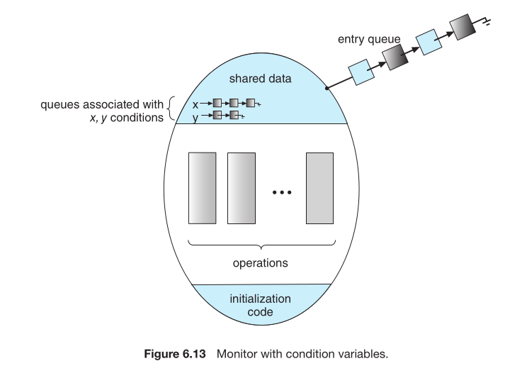

- **Entry Queue:** For threads waiting to enter the monitor.
- **Condition Queues (`x`, `y`):** Separate queues for threads that have called `x.wait()` or `y.wait()`.
- **Only one thread** is active inside the monitor rectangle at any time.

#### **Real-World Adoption**

Monitors, often with Mesa semantics, are widely implemented:

- **Java:** Every object has an intrinsic monitor lock. `synchronized` methods/blocks provide mutual exclusion. The `wait()`, `notify()`, and `notifyAll()` methods of the `Object` class correspond to `wait()` and `signal()` on condition variables.
- **C#:** The `lock` statement and `Monitor.Wait()`, `Monitor.Pulse()` (signal), `Monitor.PulseAll()` methods.
- **Other Languages:** Languages like Erlang use similar actor-based concurrency models for safe message passing.

Monitors represent a significant step towards safer, structured concurrent programming by reducing the burden of correct lock management.

### **6.7.2 Implementing a Monitor Using Semaphores**

#### **Goal: Building Monitors from Lower-Level Primitives**

We now show how a monitor (with **signal-and-wait semantics**) can be constructed using the synchronization tools we already have: **semaphores**. This demonstrates that monitors are a **higher-level abstraction** that can be implemented using lower-level mechanisms.

#### **Core Components for Mutual Exclusion**

For each monitor, we need:

1. **Binary Semaphore `mutex` (initialized to 1):** Enforces the fundamental rule: "Only one process active in the monitor." A process must call `wait(mutex)` to enter and `signal(mutex)` to exit.
2. **Binary Semaphore `next` (initialized to 0):** Used to coordinate between a **signaling process** and the **awakened process**. The signaling process suspends itself on `next` if it must wait for the awakened process to finish.
3. **Integer `next_count`:** Counts the number of processes currently suspended on the `next` semaphore.

#### **Implementing Monitor Procedures (Functions)**

Every monitor procedure `F` is translated into a structure that manages the lock and the hand-off to processes woken up by `signal()`.

**Skeleton of Translated Procedure `F`:**

```
wait(mutex);          // ENTRY: Acquire the monitor lock.

// ... body of the original function F ...

// EXIT: Before leaving, check if there are processes
//       that were signaled and are waiting on 'next'.
if (next_count > 0)
    signal(next);     // Let one of them proceed.
else
    signal(mutex);    // Otherwise, just free the monitor lock.
```

**Explanation:** The exit code ensures that if a process was awakened via a `signal()` and is waiting on `next` (because of signal-and-wait semantics), it gets to run before the signaling process fully releases the monitor. Otherwise, the monitor lock is simply released.

#### **Implementing Condition Variables**

For **each condition variable** `x` in the monitor, we need:

1. **Binary Semaphore `x_sem` (initialized to 0):** The queue where processes block when they execute `x.wait()`.
2. **Integer `x_count` (initialized to 0):** The number of processes currently waiting on condition `x`.

**Implementing `x.wait()`:**

```
// Process executes this when it needs to wait for condition x.
x_count++;                 // 1. Increment the waiters count.

// 2. Release the monitor. Who gets it next?
if (next_count > 0)
    signal(next);          // Give it to a signaled process waiting on 'next'.
else
    signal(mutex);         // Otherwise, just release the monitor lock.

wait(x_sem);               // 3. BLOCK: Suspend on the condition's queue.

x_count--;                 // 4. When resumed, we're about to re-enter. Decrement count.
```

**Logic:** The process adds itself to the waiters for `x`, then carefully releases the monitor lock, giving priority to any process already waiting on `next`. Finally, it blocks on `x_sem`. When later awakened, it proceeds, having already been granted re-entry to the monitor.

**Implementing `x.signal()`:**

```
// Process executes this to wake up one waiter on condition x.
if (x_count > 0) {          // 1. Are there any waiters?
    next_count++;           // 2. Yes. Increment count of processes waiting on 'next'.
    signal(x_sem);          // 3. Wake up ONE process waiting on condition x.
    wait(next);             // 4. SIGNAL-AND-WAIT: Suspend ourselves on 'next'.
    next_count--;           // 5. When we resume, we have the lock back. Clean up.
}
// If x_count == 0, signal() has no effect.
```

**Logic:** If there's a waiter, the signaling process:

1. Notes that it will soon wait on `next`.
2. Wakes up a waiter (on `x_sem`).
3. Immediately suspends **itself** on `next`, handing control directly to the awakened process. This is the **signal-and-wait** behavior.
4. When the awakened process eventually exits the monitor or waits again, it will `signal(next)`, resuming the original signaling process.

#### **Putting It All Together: The Flow of Control**

Imagine Monitor `M` with condition `x`.

1. Process `P1` enters (`wait(mutex)`), runs, finds a condition false, calls `x.wait()`.
   - `P1` blocks on `x_sem`. The monitor lock is released (via `signal(mutex)`).
2. Process `P2` now enters (`wait(mutex)`), runs, makes condition true, calls `x.signal()`.
   - Since `x_count > 0`, `P2` increments `next_count`, wakes `P1` (`signal(x_sem)`), and immediately blocks itself on `wait(next)`.
3. Process `P1`, now awakened, proceeds from its `wait(x_sem)`. It has the logical lock.
   - `P1` runs, eventually finishes its procedure.
   - On exit, `P1` sees `next_count > 0`, so it calls `signal(next)`, which wakes up `P2`.
4. Process `P2` resumes from `wait(next)`, completes its procedure.
   - On exit, `P2` sees `next_count` is now 0, so it calls `signal(mutex)`, finally releasing the monitor lock.

#### **Example Monitor (Go to Figure 6.14)**

**Figure 6.14** shows a simple monitor for allocating a single resource.

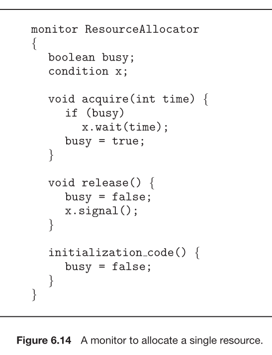

- **Shared Data:** `boolean busy`.
- **Condition:** `x` (for processes to wait if the resource is busy).
- **Procedure `acquire()`:** If `busy` is true, wait on `x`. Then set `busy = true`.
- **Procedure `release()`:** Set `busy = false` and signal `x`.

Using the semaphore implementation described above, this high-level, safe monitor code can be automatically translated into correct, low-level semaphore operations that manage all the locking and condition queueing.

**Final Note:** This implementation provides a general proof-of-concept. Real systems may optimize it (e.g., for signal-and-continue semantics, or using native OS support), but the core ideas of using a `mutex` semaphore and separate condition semapheres remain fundamental.

### **6.7.3 Resuming Processes within a Monitor**

#### **Scheduling Which Waiting Process Resumes**

When multiple processes are suspended on the same condition variable `x` (via `x.wait()`), and a `x.signal()` is called, a decision must be made: **which waiting process gets to resume?** The default, simplest policy is **First-Come, First-Served (FCFS)**, where the longest-waiting process is resumed first.

However, FCFS is not always suitable. We often need **priority-based scheduling** (e.g., resuming the process with the shortest upcoming task first to improve system throughput). To support this, monitors can provide a **conditional-wait** construct.

#### **The Conditional-Wait Construct**

**Syntax:** `x.wait(c);`

- `x` is a condition variable.
- `c` is an integer expression (evaluated at the time of the `wait()` call) called the **priority number**. This number is stored alongside the suspended process's ID in the condition queue.

**Resumption Rule:** When `x.signal()` is executed, the process **with the smallest priority number** (i.e., highest priority, where lower number often means higher priority) is selected to resume next, not necessarily the one that waited longest.

#### **Example: Priority-Based Resource Allocation**

Consider the **ResourceAllocator** monitor from **Figure 6.14**, modified to use conditional wait. The goal: allocate a single resource to the process that requests it for the **shortest duration**, minimizing the time others must wait.

**Modified `acquire()` procedure (conceptual):**

```
void acquire(int time) {
    if (busy)
        x.wait(time);  // 'time' is the priority number! Shorter time = higher priority.
    busy = true;
}
```

- A process requesting the resource specifies `time` (its planned usage duration).
- If the resource is busy (`busy == true`), the process calls `x.wait(time)`, using `time` as its priority number.
- The monitor's internal queue for condition `x` orders waiting processes by this `time` value.
- When the current holder calls `release()` and `x.signal()`, the process with the **smallest `time` value** (shortest requested duration) is awakened and granted the resource next.

This implements a **shortest-job-first (SJF)** scheduling policy for the resource.

#### **The Persistent Problem: Correct Usage is Not Enforced**

Monitors automate mutual exclusion and condition signaling, but they **cannot enforce correct protocol sequences** at the application level. The programmer must still use the monitor correctly, and errors can break everything.

**Required Protocol for the ResourceAllocator:**

```
R.acquire(t);  // 1. Request access with time t.
// 2. Access the resource...
R.release();   // 3. Release the resource.
```

**Potential Programmer Errors (same as with semaphores):**

1. **Access without acquiring:** Skipping `acquire()`. ➜ **Mutual exclusion violated.**
2. **Fail to release:** Skipping `release()`. ➜ **Resource permanently locked, deadlock.**
3. **Release without acquiring:** Calling `release()` without ownership. ➜ **Corrupts state (`busy` becomes false while no one holds it).**
4. **Double acquire:** Calling `acquire()` twice without an intervening release. ➜ **Deadlocks itself.**

These are **logical errors in program flow**, not synchronization errors. The monitor's automatic locking doesn't protect against them.

#### **Why This is a Fundamental Limitation**

1. **The Monitor is a Gateway, Not a Enforcer:** The monitor controls access to the *shared data* (`busy` variable) but not to the **physical resource itself**. A buggy or malicious process could bypass the monitor entirely and access the resource directly if the OS/hardware allows it.
2. **Correctness Depends on Client Code:** To ensure the system works, we must:
   - **Verify all user processes** call the monitor procedures in the correct sequence (`acquire` before `release`, etc.).
   - **Ensure no process** ignores the monitor and touches the resource directly.

For small, well-controlled systems (like an OS kernel), this manual verification might be possible. For large, dynamic systems with arbitrary user code, **it is impossible to guarantee**.

#### **The Path Forward: Stronger Mechanisms**

This access-control problem—ensuring that resources are **only** accessed through specific, proper protocols—cannot be solved by synchronization tools alone. It requires **system-level security and protection mechanisms**.

**Solution Preview (See Chapter 17):**

- **Hardware and OS support** are needed to enforce **mandatory access control**.
- Mechanisms like **capabilities** or **access control lists (ACLs)** can be used to grant processes the right to *call specific monitor functions* only, not to access the underlying resource directly.
- The operating system kernel can act as a reference monitor, intercepting all resource access attempts and validating them against a security policy.

**Conclusion:** Monitors provide excellent **structured synchronization** but do not solve the broader **resource protection** problem. They move the correctness burden from low-level lock management to high-level protocol adherence, but final assurance requires comprehensive system security design.

## **6.8 Liveness**

#### **Introduction: The Problem of Indefinite Waiting**

Synchronization tools are meant to solve the critical-section problem, but their use can introduce a new class of problems: **processes may get stuck and fail to make progress.** This violates the **progress** and **bounded-waiting** requirements.

**Liveness** is a set of system properties that guarantee processes make forward progress during their lifecycle. A **liveness failure** occurs when this guarantee is broken. Symptoms include poor performance, unresponsiveness, and hangs. Examples include infinite loops and, in concurrent programming, specific failures caused by synchronization.

We examine two major types of liveness failures: **Deadlock** and **Starvation** (covered next).

### **6.8.1 Deadlock**

#### **Definition of Deadlock**

A **deadlock** occurs when a set of processes are **each waiting for an event that can only be caused by another process in the same set**. In the context of synchronization, the "event" is typically the **release of a resource** (a mutex lock, a semaphore, or a condition variable signal).

When deadlocked, **no process in the set can ever make progress**; they are permanently stuck unless external intervention occurs.

#### **Classic Deadlock Illustration with Two Semaphores**

Consider two processes, `P0` and `P1`, and two binary semaphores, `S` and `Q`, both initialized to 1.

**Process P0 executes:**

```
wait(S);  // Acquires S.
wait(Q);  // Waits to acquire Q.
// ... Critical section using both S and Q ...
signal(S);
signal(Q);
```

**Process P1 executes:**

```
wait(Q);  // Acquires Q.
wait(S);  // Waits to acquire S.
// ... Critical section using both S and Q ...
signal(Q);
signal(S);
```

**Possible Interleaving Leading to Deadlock:**

1. `P0` executes `wait(S)` and acquires **S**.
2. `P1` executes `wait(Q)` and acquires **Q**.
3. `P0` executes `wait(Q)`. Since `Q` is held by `P1`, `P0` **blocks**.
4. `P1` executes `wait(S)`. Since `S` is held by `P0`, `P1` **blocks**.

**Result: Deadlock.**

- `P0` is waiting for `P1` to `signal(Q)`.
- `P1` is waiting for `P0` to `signal(S)`.
- Neither can ever proceed to execute its `signal()` operation. Both wait forever.

#### **The Necessary Conditions for Deadlock**

For a deadlock to be possible, four conditions must hold simultaneously (this is explored in depth in Chapter 8):

1. **Mutual Exclusion:** Resources (like semaphores) are non-shareable (only one process can hold them at a time).
2. **Hold and Wait:** A process holds at least one resource while waiting to acquire additional resources held by other processes.
3. **No Preemption:** Resources cannot be forcibly taken away from a process; they must be released voluntarily.
4. **Circular Wait:** A circular chain of processes exists where each process is waiting for a resource held by the next process in the chain (e.g., `P0` waits for `P1`, `P1` waits for `P0`).

In our example, the circular wait is clear: `P0 -> Q (held by P1) -> P1 -> S (held by P0) -> P0`.

#### **Preventing the Example Deadlock**

A common solution is to **enforce a total ordering** on all resource acquisitions. If every process acquires resources in the same, globally defined order, a circular wait cannot occur.

**Fix:** Define the order as **S before Q**. Rewrite `P1` to follow the same order:

```
// P1 (Corrected)
wait(S);  // Acquire S first, just like P0.
wait(Q);  // Then acquire Q.
// ...
signal(Q);
signal(S);
```

Now, even if `P0` acquires `S` first, `P1` will block on `wait(S)` and cannot acquire `Q`. This prevents the hold-and-wait scenario that leads to a circle. Deadlock is impossible.

**Key Takeaway:** Deadlock is a severe liveness failure where processes are permanently blocked. Careful design of locking protocols (like lock ordering) is necessary to prevent it. Chapter 8 will discuss deadlock in greater detail, including detection, prevention, and avoidance strategies.

### **6.8.2 Priority Inversion**

#### **The Problem: High-Priority Process Blocked by Low-Priority Process**

**Priority inversion** is a specific liveness failure that occurs in **priority-based scheduling** systems (where a higher-priority process should always run before a lower-priority one). It breaks this fundamental expectation.

**Scenario Setup:**

- Three processes with priorities: **L** (Low), **M** (Medium), **H** (High). So: **Priority(L) < Priority(M) < Priority(H)**.
- A shared resource (e.g., a kernel data structure) protected by a lock/semaphore `S`.

**The Deadly Sequence:**

1. **Low-priority process L** acquires the lock `S` and begins using the shared resource.
2. **High-priority process H** becomes ready and preempts `L` (as expected). `H` tries to acquire lock `S` but finds it held by `L`. `H` **blocks**, waiting for `L` to release `S`.
3. At this point, `L` should run (to finish and release `S` so `H` can run). However...
4. **Medium-priority process M** becomes ready. Since `M` has higher priority than `L`, it **preempts `L`** and starts running.
5. **Result:** Process `H` (the highest priority) is now **indirectly blocked by `M`** (a medium-priority process), even though `H` and `M` do not share any resource. `H` must wait not only for `L` to finish, but for **`M` (and any other medium-priority processes) to finish as well**, because `M` prevents `L` from making progress. This inverts the expected priority order.

**Impact:** The high-priority process `H` may be delayed for an **unbounded amount of time** by lower-priority processes, violating real-time guarantees and causing severe responsiveness issues.

#### **The Solution: Priority-Inheritance Protocol**

The core fix is to temporarily **boost the priority** of the low-priority process holding a resource that a high-priority process needs. This is the **priority-inheritance protocol**.

**How it works (applied to the example):**

1. Process `L` (Low) acquires lock `S`.
2. Process `H` (High) tries to acquire `S` and blocks.
3. **Inheritance Triggered:** The system detects that `H` is blocked waiting for a resource held by `L`. Therefore, `L` **inherits the priority of `H`**. `L`'s priority is temporarily raised to match `H`'s priority.
4. Now, when process `M` (Medium) becomes ready, it **cannot preempt `L`**, because `L` now has a priority equal to `H` (which is higher than `M`'s).
5. Process `L` continues running at high priority, finishes its work with resource `S`, and releases the lock.
6. **Priority Reversion:** Upon releasing `S`, `L` **loses its inherited priority** and reverts to its original low priority.
7. **Correct Scheduling Resumes:** Lock `S` is now free. The scheduler will now run the highest-priority ready process, which is **`H`**. Process `H` acquires `S` and runs. Only after `H` blocks or finishes would `M` get a chance to run.

**Key Effect:** The inheritance protocol prevents medium-priority processes from extending the blocking time of the high-priority process. The blocking time is now limited to the **worst-case execution time of the critical section of the low-priority process** (`L`), not an arbitrary chain of medium-priority processes.

#### **Significance**

Priority inversion is a critical concern in:

- **Real-Time Operating Systems (RTOS)** where missing deadlines can be catastrophic.
- Any system with priority scheduling and shared resources (including mainstream OS kernels).

The **priority-inheritance protocol** is a widely implemented solution (e.g., in the POSIX standard and many RTOSes). It ensures that priority inversion is **bounded** and does not lead to indefinite postponement of high-priority tasks.

## **6.9 Evaluation**

#### **Choosing the Right Synchronization Tool**

We have covered multiple synchronization tools, from hardware instructions to high-level abstractions. All can ensure mutual exclusion when used correctly, but **performance and suitability vary greatly**. Choosing the right tool is crucial for building efficient concurrent systems. Here is a strategic guide.

#### **Low-Level Foundation: Hardware Instructions**

- **Role:** `test_and_set()`, `compare_and_swap()` (CAS), and memory barriers are **low-level primitives**. They are rarely used directly by application programmers but are the **building blocks** for all higher-level synchronization tools (mutexes, semaphores).
- **Modern Trend - Lock-Free Algorithms:** CAS is increasingly used to build **lock-free** (or non-blocking) data structures. These algorithms avoid traditional locks by using optimistic collision detection: attempt an update with CAS; if it fails (because another thread modified the data), retry.
  - **Philosophy:** CAS is **optimistic**. Assume no conflict, then detect and recover.
  - **Vs. Traditional Locks:** Mutex locks are **pessimistic**. Assume conflict, so acquire exclusive access before proceeding.
  - **Challenge:** Lock-free algorithms are **notoriously difficult** to design and prove correct.

#### **Performance Comparison: CAS vs. Traditional Locks**

The choice between CAS-based approaches and traditional locking (mutex/semaphore) depends heavily on **contention**—how many threads compete for the resource simultaneously.

1. **Uncontended (No Competition):**
   - **Both are very fast.** CAS is **somewhat faster** because it involves a single atomic hardware instruction, while a mutex lock requires a few more instructions for the lock acquisition path.
2. **Moderate Contention:**
   - **CAS is generally faster—often significantly so.** Why?
     - In the CAS retry loop, failures are usually resolved after a few spins. The thread **never leaves the CPU** (no context switch).
     - With a contended mutex, a failing `acquire()` leads to the thread being **suspended, placed on a wait queue, and a context switch**—a heavy-weight operation involving kernel intervention. The cost of two context switches often outweighs a few CAS retries.
3. **High Contention:**
   - **Traditional locking (with blocking) becomes preferable.** Under extreme contention, the CAS approach suffers from **cache line bouncing** (many CPUs constantly reading/writing the same memory location, invalidating each other's caches) and **starvation risk** (some threads may retry indefinitely). The overhead of many threads spinning wastes CPU cycles.
   - A blocking mutex, while expensive per thread, **quiets the system** by putting most threads to sleep, reducing memory contention and letting the lock holder proceed efficiently.

#### **Guidelines for Selecting Synchronization Mechanisms**

- **For Simple Counters/Updates:** Use **atomic variables** (provided by the language/OS, e.g., `std::atomic` in C++, `AtomicInteger` in Java). They are lightweight wrappers around CAS and are **far more efficient** than a mutex for a single variable update.
- **For Critical Sections on Multiprocessors:**
  - **Short-duration hold:** Use a **spinlock**. The rule of thumb: if the hold time is **less than the cost of two context switches**, spinning is more efficient. Common in OS kernels.
  - **Longer or unpredictable hold:** Use a **blocking mutex** (which may internally use a spinlock for its own short critical section, as in semaphore implementation).
- **Mutual Exclusion vs. Resource Management:**
  - For simple mutual exclusion, a **mutex lock** is simpler and has less overhead than a binary semaphore.
  - For managing a **pool of identical resources** (e.g., 5 tape drives), a **counting semaphore** is the natural fit.
  - For scenarios with many readers and few writers, a **reader-writer lock** can provide better concurrency than a plain mutex.
- **High-Level Abstractions (Monitors, Condition Variables):**
  - **Primary Appeal:** **Simplicity and safety.** They reduce programmer error by automating lock management.
  - **Cost:** They may have **higher overhead** and **less scalability** under high contention due to their inherent structure. However, they are often the best choice for application-level correctness and maintainability.

#### **Real-World Example: Priority Inversion on Mars Pathfinder**

**Highlighted Box: Priority Inversion and the Mars Pathfinder** This case study underscores that synchronization failures are not just academic. The Mars Sojourner rover in 1997 experienced repeated system resets due to undetected **priority inversion** in its VxWorks real-time OS.

- A high-priority task (`bc_dist`) was blocked waiting for a shared resource held by a low-priority task (`ASI/MET`).
- Medium-priority tasks then preempted the low-priority task, preventing it from releasing the resource, causing the high-priority task to miss its deadline.
- The watchdog timer (`bc_sched`) would then reset the entire system.
- **Solution:** Engineers on Earth enabled the **priority-inheritance protocol** (a global variable in VxWorks) **via remote command**. The low-priority task inherited the high priority while holding the resource, preventing preemption, and the problem was solved. This saved the mission.

#### **Ongoing Research and Future Directions**

The quest for better synchronization tools continues, focusing on:

- **More efficient compilers** for concurrent code.
- **Programming languages** with built-in, safe concurrency models (e.g., Rust's ownership, Go's channels, Erlang's actors).
- **Performance improvements** in existing synchronization libraries and APIs.

In the next chapter, we will see how real operating systems (Linux, Windows, macOS) and APIs (Pthreads) implement these tools in practice.

## **6.10 Summary**

#### **Core Concepts**

- **Race Condition:** A situation where multiple processes concurrently access and manipulate shared data, and the final outcome depends on the non-deterministic order of these accesses. This leads to **data corruption**.
- **Critical Section:** A segment of code where a process accesses and updates shared data. It's the region where a race condition can occur.
- **Critical-Section Problem:** The challenge of designing a protocol to ensure that when one process is in its critical section, no other process is allowed to be in theirs, thereby enabling safe data sharing.

#### **Requirements for a Correct Solution**

Any valid solution must satisfy:

1. **Mutual Exclusion:** Only one process can be active in its critical section at a time.
2. **Progress:** If no process is in its critical section and some processes want to enter, the selection of the next process must not be postponed indefinitely and must involve only those willing to enter.
3. **Bounded Waiting:** After a process requests entry to its critical section, there must be a limit on how many times other processes can enter before it does (prevents starvation).

#### **Synchronization Tools: A Hierarchy**

**1. Software Solutions (Conceptual, Not Practical):**

- **Peterson's Algorithm:** A classic two-process solution that logically satisfies all three requirements but **fails on modern hardware** due to instruction reordering.

**2. Hardware Support (The Foundation):**

- **Memory Barriers (Fences):** Instructions that prevent reordering of memory operations across the barrier, ensuring visibility to other processors.
- **Atomic Hardware Instructions (e.g., Compare-and-Swap - CAS):** Low-level instructions that perform a read-modify-write sequence indivisibly. Used to build all higher-level tools.
- **Atomic Variables:** Lightweight, language-level abstractions built on CAS for safe updates to single variables (like counters).

**3. Low-Level Synchronization Primitives:**

- **Mutex Locks:** Provide mutual exclusion. A process must **acquire** the lock before entering a critical section and **release** it after leaving.
  - **Spinlock:** A mutex implemented with busy-waiting. Efficient for very short holds on multiprocessors.
- **Semaphores:** A more general integer-based synchronization tool.
  - **Binary Semaphore:** Value 0 or 1; functions like a mutex lock.
  - **Counting Semaphore:** Can hold any non-negative integer; manages access to a pool of identical resources.

**4. High-Level Abstractions:**

- **Monitors:** An **Abstract Data Type (ADT)** that encapsulates shared data and the procedures that operate on it. The language runtime **automatically provides mutual exclusion** for all monitor procedures, making it safer and easier to use.
- **Condition Variables:** Used within monitors (or with explicit locks) to allow processes to wait for a specific condition (`wait()`) and to signal others when the condition may be true (`signal()`).

#### **Liveness Problems**

- **Liveness:** The guarantee that a system will make progress.
- **Liveness Failures:** Situations where processes cannot make progress.
  - **Deadlock:** Two or more processes are permanently blocked, each waiting for an event that can only be caused by another waiting process. (e.g., circular wait for locks).
  - **Priority Inversion:** A scheduling problem in priority-based systems where a high-priority process is forced to wait indefinitely for a low-priority process, which in turn is preempted by medium-priority processes. Solved by the **priority-inheritance protocol**.

#### **Performance Evaluation and Selection Guidelines**

The best synchronization tool depends on the **contention level**:

- **Uncontended/Low Contention:** **Atomic variables** and **CAS-based** approaches are very fast.
- **Moderate Contention:** **CAS-based** approaches often outperform traditional **blocking locks**, as they avoid costly context switches.
- **High Contention:** **Traditional blocking locks** (mutexes, semaphores) become preferable to reduce cache thrashing and CPU waste from excessive spinning.
- **General Rules:**
  - Use the **simplest, highest-level** tool that works (e.g., a monitor over hand-crafted semaphores) for safety.
  - Use a **mutex** for simple mutual exclusion.
  - Use a **counting semaphore** for managing multiple resource instances.
  - Use **spinlocks** only for very short critical sections on multiprocessors.